# Is There Gender Equality in the Pokémon Universe?

Exploring Pokémon sex ratio and building an interactive sunburst diagram.

Felix Luginbuhl

06/10/2018

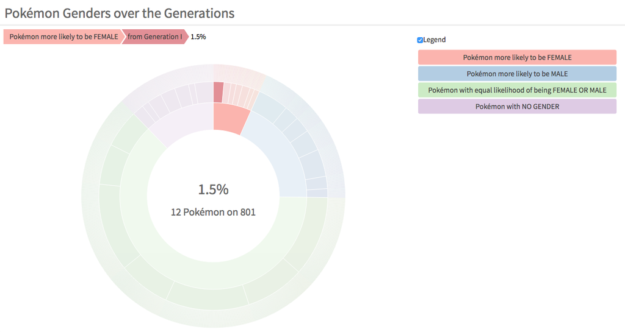

With more than 13 millions of subscribers, Reddit’s *[Data Is Beautiful](https://www.reddit.com/r/dataisbeautiful/comments/9cuzs3/battle_dataviz_battle_for_the_month_of_september/)* is one of the main online forum on data visualization. Last week I came accross the funny dataset of the current DataViz monthly challenge: [Information on All 802 Pokemon](https://www.kaggle.com/rounakbanik/pokemon). Having a quick look at the data, I discovered with surprize a `percentage_male` variable. I wasn’t aware that Pokémon have genders. So I decided to dig further into this gender dimension of the Pokémon universe.

I learnt that since the 2nd generation, Pokémon could either be male or female. For example, when a little Pikachu get out of its egg, he has 50% percent of being male (and 50% of being female). Some Pokémons have more chances to be male, some to be female and some have no genders (as I always thought). Take Squirtle for example. According to the dataset, he has 88.1% of chances to be male. Squirtle is therefore a male Pokémon.

This surprise led me to ask a simple question: **is there gender equality in the Pokémon universe?**

## Catch ’Em All

Firstly, let’s get the data and classify the Pokémon according to their more probable gender.

```r
library(tidyverse)
library(DT)

pokemon <- read_csv("input/pokemon.csv") #data from https://www.kaggle.com/rounakbanik/pokemon

pokemon_gender <- pokemon %>%
  select(percentage_male, generation, name) %>%
  mutate(gender = case_when(percentage_male == 0.0 ~ "Pokémon more likely to be FEMALE",
                            percentage_male == 11.2 ~ "Pokémon more likely to be FEMALE",
                            percentage_male == 24.6 ~ "Pokémon more likely to be FEMALE",
                            percentage_male == 50.0 ~ "Pokémon with equal likelihood of being FEMALE OR MALE",
                            percentage_male == 75.4 ~ "Pokémon more likely to be MALE",
                            percentage_male == 88.1 ~ "Pokémon more likely to be MALE",
                            percentage_male == 100.0 ~ "Pokémon more likely to be MALE"),
         gender = replace_na(gender, "Pokémon with NO GENDER"), #NA is for genderless
         generation = case_when(generation == 1 ~ "from Generation I",
                                generation == 2 ~ "from Generation II",
                                generation == 3 ~ "from Generation III",
                                generation == 4 ~ "from Generation IV",
                                generation == 5 ~ "from Generation V",
                                generation == 6 ~ "from Generation VI",
                                generation == 7 ~ "from Generation VII")) %>%
  count(gender, generation, name) #mutate(n = 1) would also work

datatable(select(pokemon_gender, name, generation, gender), rownames = FALSE,
          options = list(pageLength = 5, dom = 'ftpi'))
```

| name | generation | gender |
| --- | --- | --- |
| Chansey | from Generation I | Pokémon more likely to be FEMALE |
| Clefable | from Generation I | Pokémon more likely to be FEMALE |
| Clefairy | from Generation I | Pokémon more likely to be FEMALE |
| Jigglypuff | from Generation I | Pokémon more likely to be FEMALE |
| Jynx | from Generation I | Pokémon more likely to be FEMALE |
| Kangaskhan | from Generation I | Pokémon more likely to be FEMALE |
| Nidoqueen | from Generation I | Pokémon more likely to be FEMALE |
| Nidoran♀ | from Generation I | Pokémon more likely to be FEMALE |
| Nidorina | from Generation I | Pokémon more likely to be FEMALE |
| Ninetales | from Generation I | Pokémon more likely to be FEMALE |

[output cut: 791 more lines]

## Visualize ’Em all

A simple treemap allows us to visualize our hierarchical dataset.

```r
library(treemap)

pokemon_tm <- treemap(pokemon_gender,
                      index = c("gender", "generation", "name"),
                      vSize = "n",
                      palette = "Pastel1",
                      title = "Pokémon Genders over the Generations")
```

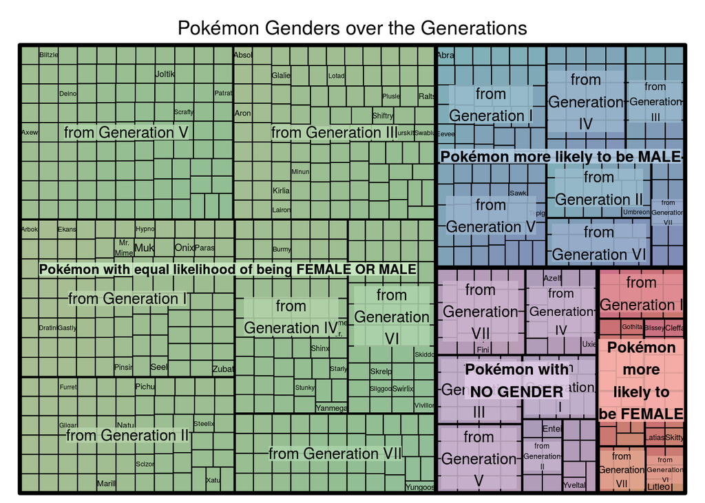

Looks like gender imbalance to me. The `Pokémon more likely to be FEMALE` cell is less than half the size of the `Pokémon more likely to be MALE` cell.

The `sunburstR` package, a htmlwidget to create d3.js sequence sunbursts, allows us to better explore the Pokémon gender repartition over the generations.

We get a simple but effective interactive visualization, which I published online using `flexdashboard`. Note that some modification have to be made manually inside the HTML output.

Click on the image to open the interactive page.

```r
library(sunburstR)
library(d3r)
library(htmlwidgets)

pokemon_tm_nest <- d3_nest(
  pokemon_tm$tm[,c("gender", "generation", "name", "vSize", "color")],
  value_cols = c("vSize", "color")
  )

sb <- sunburst(
  data = pokemon_tm_nest,
  valueField = "vSize",
  legend = list(w = 400),
  legendOrder = c("Pokémon more likely to be FEMALE",
                  "Pokémon more likely to be MALE",
                  "Pokémon with equal likelihood of being FEMALE OR MALE",
                  "Pokémon with NO GENDER"),
  count = TRUE,
  sumNodes = FALSE,
  colors = htmlwidgets::JS("function(d){return d3.select(this).datum().data.color;}"),
  withD3 = TRUE)

sb <- htmlwidgets::onRender(sb,
  #ref: https://github.com/timelyportfolio/sunburstR/issues/15
  "function(el,x){
  // have legend as default
    d3.select(el).select('.sunburst-togglelegend').property('checked', true);
    d3.select(el).select('.sunburst-legend').style('visibility', '');
  }"
  )
```

```javascript
## code to copy past into the equivalent html output

// Fade all but the current sequence, and show it in the breadcrumb trail.
  function mouseover(d) {

    var percentage = (100 * d.value / totalSize).toPrecision(2); // precision 2 - lgnbhl mod
    var percentageString = percentage + "%";
    if (percentage < 0.13) { // conditionality added
      percentageString = "";
    }

    var countString = [
        '<span style = "font-size:.7em">',
        d3Format.format("1.2s")(d.value) + ' Pokémon on 801', // on 801 Pokémon
        '</span>'
      ].join('');
    if (percentage < 0.13) { // conditionality added
      countString = d.data.name;
    }
```

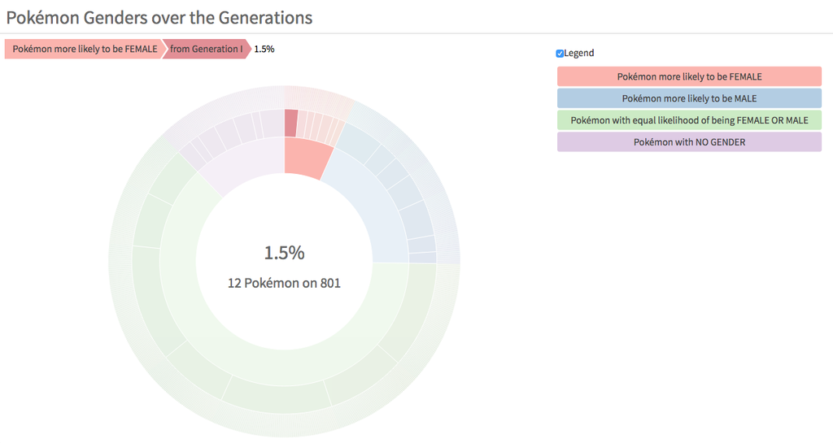

Thanks for reading. For updates of recent blog posts, follow me on [Twitter](https://twitter.com/lgnbhl).